# Shipra_Gupta_Final_Project

### Data cleaning

```python
# removed the extra space from Native-country column values
df['Native-country'] = df['Native-country'].str.strip()
```

```python
# checked other categorical columns for missing names
df['Workclass'].unique()
```

```
array([' State-gov', ' Self-emp-not-inc', ' Private', ' Federal-gov',
       ' Local-gov', ' ?', ' Self-emp-inc', ' Without-pay',
       ' Never-worked'], dtype=object)
```

```python
# removed the extra space from workclass column values
df['Workclass'] = df['Workclass'].str.strip()
```

```python
# checked other categorical columns for missing names
df['Native-country'].unique()
```

```
array(['United-States', 'Cuba', 'Jamaica', 'India', '?', 'Mexico',
       'South', 'Puerto-Rico', 'Honduras', 'England', 'Canada', 'Germany',
       'Iran', 'Philippines', 'Italy', 'Poland', 'Columbia', 'Cambodia',
       'Thailand', 'Ecuador', 'Laos', 'Taiwan', 'Haiti', 'Portugal',
       'Dominican-Republic', 'El-Salvador', 'France', 'Guatemala',
       'China', 'Japan', 'Yugoslavia', 'Peru',
       'Outlying-US(Guam-USVI-etc)', 'Scotland', 'Trinadad&Tobago',
       'Greece', 'Nicaragua', 'Vietnam', 'Hong', 'Ireland', 'Hungary',
       'Holand-Netherlands'], dtype=object)
```

```python
# checked other categorical columns for missing names
df['Occupation'].unique()
```

```
array([' Adm-clerical', ' Exec-managerial', ' Handlers-cleaners',
       ' Prof-specialty', ' Other-service', ' Sales', ' Craft-repair',
       ' Transport-moving', ' Farming-fishing', ' Machine-op-inspct',
       ' Tech-support', ' ?', ' Protective-serv', ' Armed-Forces',
       ' Priv-house-serv'], dtype=object)
```

```python
# removed the extra space from Occupation column values
df['Occupation'] = df['Occupation'].str.strip()
```

```python
# replace all ? with unknown as they are for categorical variable
replacements = {'Workclass': {'?': 'Unknown'},
               'Occupation': {'?': 'Unknown'},
               'Native-country': {'?': 'Unknown'}
               }
df.replace(replacements, inplace=True)
```

```python
# Check the replacement in occupation column
df['Occupation'].value_counts()
```

```
Occupation
Prof-specialty       4140
Craft-repair         4099
Exec-managerial      4066
Adm-clerical         3770
Sales                3650
Other-service        3295
Machine-op-inspct    2002
Unknown              1843
Transport-moving     1597
Handlers-cleaners    1370
Farming-fishing       994
Tech-support          928
Protective-serv       649
Priv-house-serv       149
Armed-Forces            9
Name: count, dtype: int64
```

```python
# Check the replacement in native-country column
df['Native-country'].value_counts()
```

```
Native-country
United-States                 29170
Mexico                          643
Unknown                         583
Philippines                     198
Germany                         137
Canada                          121
Puerto-Rico                     114
El-Salvador                     106
India                           100
Cuba                             95
England                          90
Jamaica                          81
South                            80
China                            75
Italy                            73
Dominican-Republic               70
Vietnam                          67
Guatemala                        64
Japan                            62
Poland                           60
Columbia                         59
Taiwan                           51
Haiti                            44
Iran                             43
Portugal                         37
Nicaragua                        34
Peru                             31
France                           29
Greece                           29
Ecuador                          28
Ireland                          24
Hong                             20
Cambodia                         19
Trinadad&Tobago                  19
Laos                             18
Thailand                         18
Yugoslavia                       16
Outlying-US(Guam-USVI-etc)       14
Honduras                         13
Hungary                          13
Scotland                         12
Holand-Netherlands                1
Name: count, dtype: int64
```

```python
# Calculate the workclass % from counts
workclass_df = df['Workclass'].value_counts()/df['Workclass'].count()
workclass_df.head(2)
```

```
Workclass
Private             0.697030
Self-emp-not-inc    0.078038
Name: count, dtype: float64
```

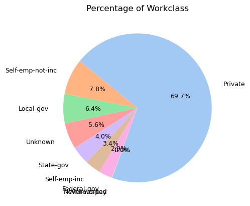

```python
# Distribution of Workclass
fig1,ax1=plt.subplots()

# Define Seaborn color palette to use
colors = sns.color_palette('pastel')[0:9]
ax1.pie(workclass_df, colors = colors, labels = workclass_df.index, autopct='%.1f%%', labeldistance=1.2, startangle=250, textprops={'fontsize': 9})

plt.title("Percentage of Workclass")
```

```python
# calculate the occupation % from counts
occupation_df = df['Occupation'].value_counts()/df['Occupation'].count()
occupation_df.head(2)
```

```
Occupation
Prof-specialty    0.127146
Craft-repair      0.125887
Name: count, dtype: float64
```

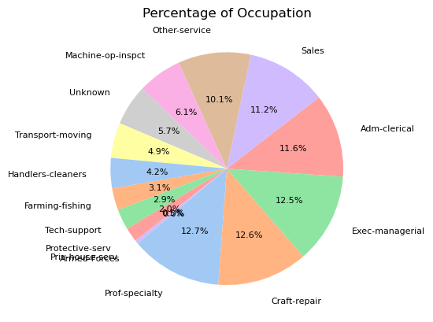

```python
# Distribution of Occupation
fig1,ax1=plt.subplots()

# Define Seaborn color palette to use
colors = sns.color_palette('pastel')[0:9]
ax1.pie(occupation_df, colors = colors, labels = occupation_df.index, autopct='%.1f%%', labeldistance=1.2, startangle=220, textprops={'fontsize': 8})

plt.title("Percentage of Occupation")
```

### Q1. How is education distributed among different racial groups?

```python
# perform a groupby on race and perform a count on each education level within each racial group using value_counts()
education_race = df.groupby('Race')['Education'].value_counts().unstack()
education_race
```

| Education Race | 10th | 11th | 12th | 1st-4th | 5th-6th | 7th-8th | 9th | Assoc-acdm | Assoc-voc | Bachelors | Doctorate | HS-grad | Masters | Preschool | Prof-school | Some-college |
| --- | --- | --- | --- | --- | --- | --- | --- | --- | --- | --- | --- | --- | --- | --- | --- | --- |
| Amer-Indian-Eskimo | 16.0 | 14.0 | 5.0 | 4.0 | 2.0 | 9.0 | 5.0 | 8.0 | 19.0 | 21.0 | 3.0 | 119.0 | 5.0 | NaN | 2.0 | 79.0 |
| Asian-Pac-Islander | 13.0 | 21.0 | 9.0 | 5.0 | 18.0 | 11.0 | 9.0 | 29.0 | 38.0 | 289.0 | 28.0 | 226.0 | 88.0 | 6.0 | 41.0 | 208.0 |
| Black | 133.0 | 153.0 | 70.0 | 16.0 | 21.0 | 56.0 | 89.0 | 107.0 | 112.0 | 330.0 | 11.0 | 1174.0 | 86.0 | 5.0 | 15.0 | 746.0 |
| Other | 9.0 | 10.0 | 14.0 | 9.0 | 13.0 | 17.0 | 8.0 | 8.0 | 6.0 | 33.0 | 2.0 | 78.0 | 7.0 | 2.0 | 4.0 | 51.0 |
| White | 762.0 | 977.0 | 335.0 | 134.0 | 279.0 | 553.0 | 403.0 | 915.0 | 1207.0 | 4682.0 | 369.0 | 8904.0 | 1537.0 | 38.0 | 514.0 | 6207.0 |

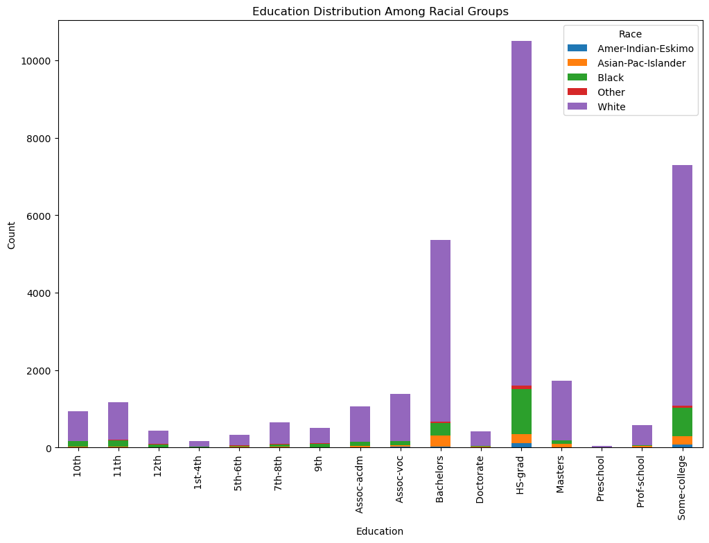

```python
# Visualization plot to see the education distribution among various racial group
ax = education_race.transpose().plot(kind='bar', stacked=True, figsize=(12, 8))

# Add labels
ax.set_xlabel('Education')
ax.set_ylabel('Count')
ax.set_title('Education Distribution Among Racial Groups')

# Show the plot
plt.show()
```

White population represents the highest education seeker overall. They seem to attain High-school, associate degrees, Bacherlors, some college degrees and some Masters. Second is black population which represents High school, some college degree, Bachelor and even doctorate degrees. Third is Asian-pacific Islander which represents High school, some college degree and Bachelor degrees. The 'Other' race shows the least study pursued in Bacherlors, High school and some college degree.

##### Bias: In US, High school means 9th, 10, 11th and 12th but in this data, I see all of them as cateogries.

### Q2. How is income correlating with different variables like education, workclass, occupation, race, marital status and sex?

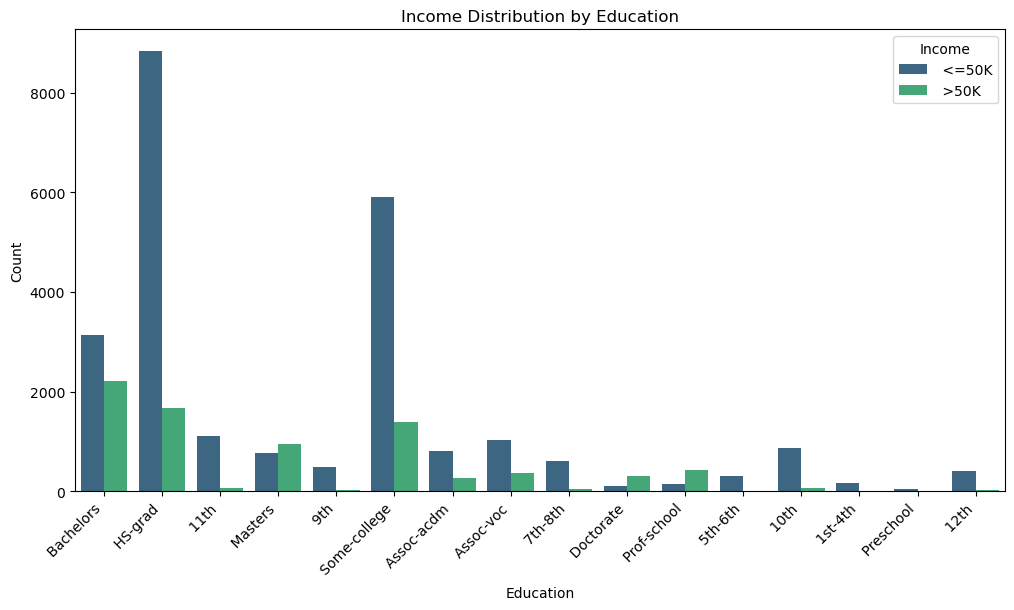

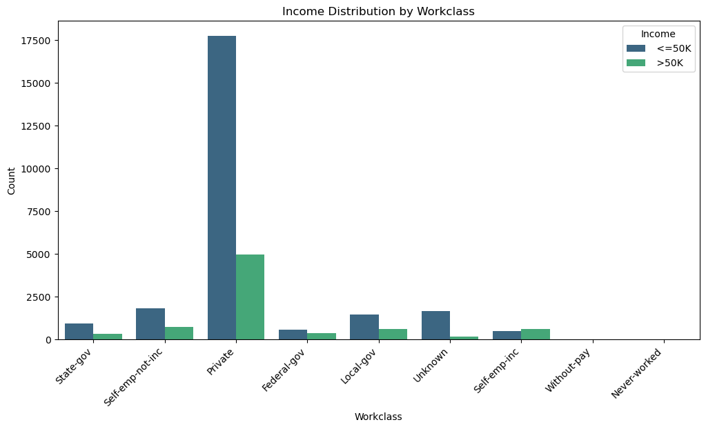

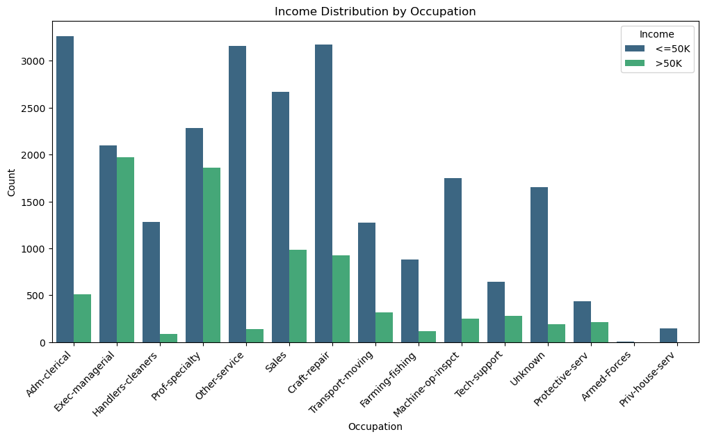

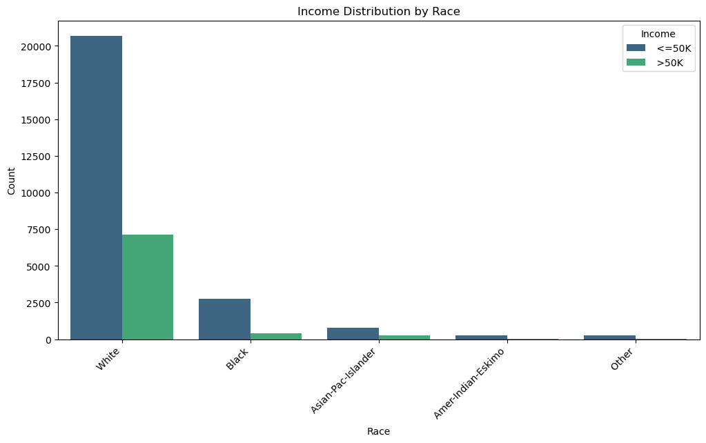

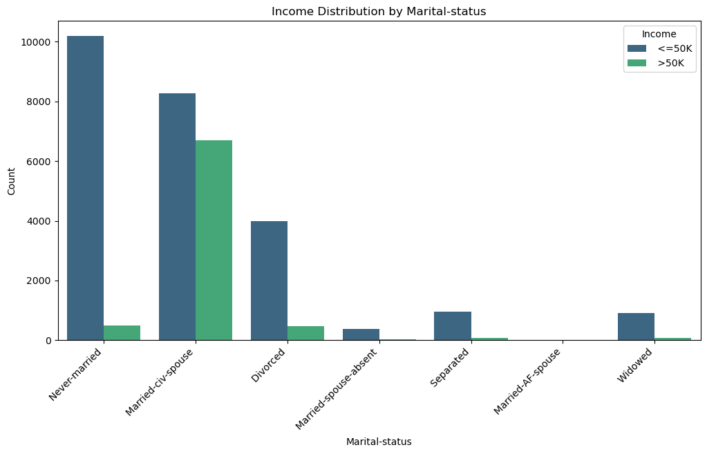

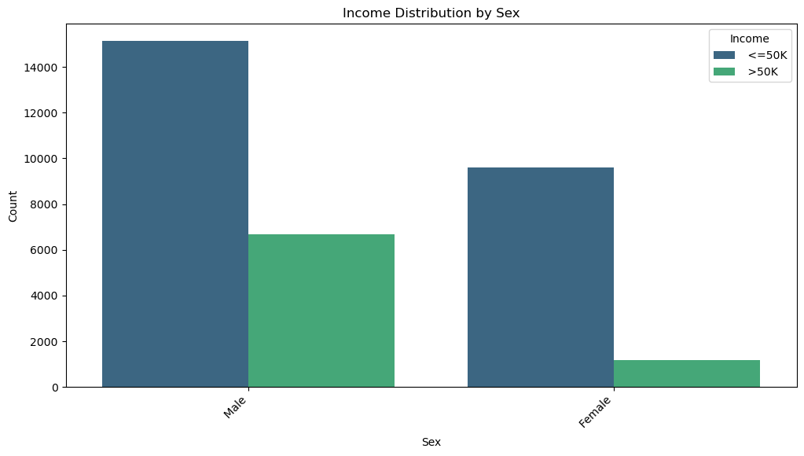

```python
# Analyze the impact of individual features on income using grouped bar plots
features_of_interest = ['Education', 'Workclass', 'Occupation', 'Race', 'Marital-status', 'Sex']

for feature in features_of_interest:
    plt.figure(figsize=(12, 6))
    sns.countplot(x=feature, hue='Income', data=df, palette='viridis')
    plt.title(f'Income Distribution by {feature}')
    plt.xlabel(feature)
    plt.ylabel('Count')
    plt.xticks(rotation=45, ha='right')
    plt.show()
```

### Income distribution by education

- Based on education, this plot tells us that people who earned high school graduate, some college and bachelor’s degrees (top 3) earned <=50k income. Higher education does show higher income.
- However, people who earned a Doctorate and Prof-school earned >50k income.
- There are less number of people who earned 5-6th, 10th, 1st-4th, preschool, and 12th class earned <=50k.

### Income distribution by Race

- White represents very high income slab than the rest.

### Income distribution by Marital status

- The people who are never married represent the highest and have <=50k income
- The people who are married-civilian-spouse represent the second highest have <=50k income. They also have a high income with >50k which may conclude the combined salary of spouse.

### Income distribution by Sex

- Male has more earning than female.
- Male earns <=50k than >50k.
- Female earns <=50k than >50k.

### Q3. Explore the relationship between Age and number of hours worked per week?

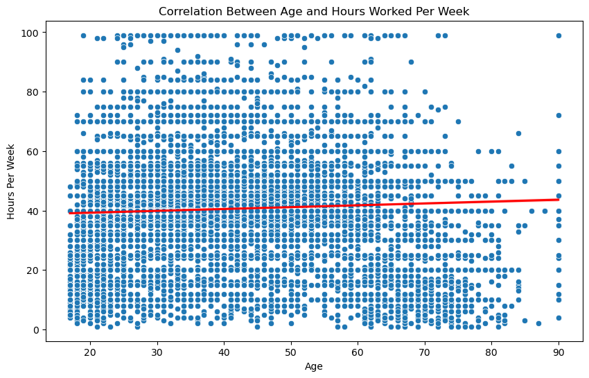

```
Correlation between Age and Hours Per Week: 0.06875570750955737
```

```python
plt.figure(figsize=(10, 6))
sns.scatterplot(x='Age', y='Hours-per-week', data=df)

# Add a linear regression line
sns.regplot(x='Age', y='Hours-per-week', data=df, scatter=False, color='red')
plt.title('Correlation Between Age and Hours Worked Per Week')
plt.xlabel('Age')
plt.ylabel('Hours Per Week')
plt.show()

# Calculate and display the correlation coefficient
correlation = df['Age'].corr(df['Hours-per-week'])
print(f'Correlation between Age and Hours Per Week: {correlation}')
```

The correlation between Age and Hours Per Week is positive but very weak.

```python
# draw a correlation between age, hours-per-week and education number
df_age_work_hours = df[['Age', 'Hours-per-week', 'Education-num']]
df_age_work_hours_corr = df_age_work_hours.corr()
df_age_work_hours_corr
```

|  | Age | Hours-per-week | Education-num |
| --- | --- | --- | --- |
| Age | 1.000000 | 0.068756 | 0.036527 |
| Hours-per-week | 0.068756 | 1.000000 | 0.148123 |
| Education-num | 0.036527 | 0.148123 | 1.000000 |

```python
# Define dependent variables
dep_variable = df_age_work_hours['Age']
dep_variable.head(2)
```

```
0    39
1    50
Name: Age, dtype: int64
```

```python
# Define independent variables
ind_variable = df_age_work_hours.drop(columns=['Age'])
ind_variable['constant'] = 1
ind_variable.head(2)
```

|  | Hours-per-week | Education-num | constant |
| --- | --- | --- | --- |
| 0 | 40 | 13 | 1 |
| 1 | 13 | 13 | 1 |

```python
# linear regression analysis
model = sm.OLS(dep_variable, ind_variable) # defined the model
results = model.fit() # fit the model
print(results.summary()) # print the results summary
```

```
                            OLS Regression Results
==============================================================================
Dep. Variable:                    Age   R-squared:                       0.005
Model:                            OLS   Adj. R-squared:                  0.005
Method:                 Least Squares   F-statistic:                     88.99
Date:                Fri, 12 Jan 2024   Prob (F-statistic):           2.87e-39
Time:                        11:24:04   Log-Likelihood:            -1.3120e+05
No. Observations:               32561   AIC:                         2.624e+05
Df Residuals:                   32558   BIC:                         2.624e+05
Df Model:                           2
Covariance Type:            nonrobust
==================================================================================
                     coef    std err          t      P>|t|      [0.025      0.975]
----------------------------------------------------------------------------------
Hours-per-week     0.0715      0.006     11.589      0.000       0.059       0.084
Education-num      0.1428      0.030      4.819      0.000       0.085       0.201
constant          34.2489      0.368     93.166      0.000      33.528      34.969
==============================================================================
Omnibus:                     1959.290   Durbin-Watson:                   1.992
Prob(Omnibus):                  0.000   Jarque-Bera (JB):             2337.941
Skew:                           0.656   Prob(JB):                         0.00
Kurtosis:                       2.989   Cond. No.                         212.
==============================================================================

Notes:
[1] Standard Errors assume that the covariance matrix of the errors is correctly specified.
```

R-squared value is very low. This model explains a small fraction of variance in Age. Both predictor variables (education-num and hours-per-week) have low p-values indicating that model is statistically significant. F-stats tests the overall significance of the model. Here high f-stats value and p-value indicates moel is statisticall significant. But, further exploration and consideration can be done by adding new variables like income as a numerical value.

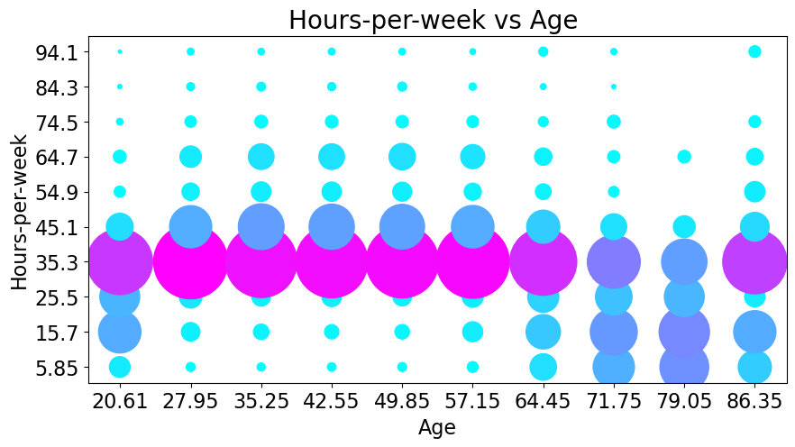

```python
# Explore if there is any relationship between 'Age' and number of work 'Hours-per-week'.
plt.figure(figsize=(10, 8))
bubble_plot(df,'Age','Hours-per-week', normalization_by_all=False)
```

### Q6. What is the median age of people with >50k income?

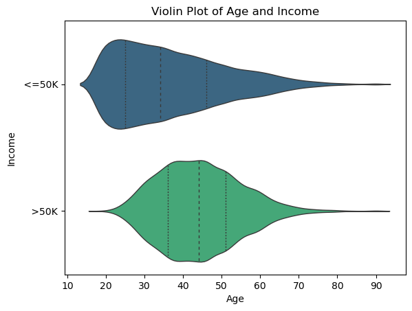

```python
# Create a violin plot using seaborn to visualize Age vs income pattern
sns.violinplot(data=df, x='Age', y='Income', palette='viridis', inner="quart", linewidth=1)

# Set plot labels and title
plt.xlabel('Age')
plt.ylabel('Income')
plt.title('Violin Plot of Age and Income')

# Show the plot
plt.show()
```

The median age for income <=50k is 35 years old and for >50k is 45 years old.

#### Q7. Is there any difference in pattern of analysis US and other countries?

### Investigate the same analysis in just US.

```python
# Subset US country dataset
US_country_df = df.loc[df['Native-country'] == 'United-States']
US_country_df.head()
```

|  | Age | Workclass | Fnlwgt | Education | Education-num | Marital-status | Occupation | Relationship | Race | Sex | Capital-gain | Capital-loss | Hours-per-week | Native-country | Income |
| --- | --- | --- | --- | --- | --- | --- | --- | --- | --- | --- | --- | --- | --- | --- | --- |
| 0 | 39 | State-gov | 77516 | Bachelors | 13 | Never-married | Adm-clerical | Not-in-family | White | Male | 2174 | 0 | 40 | United-States | <=50K |
| 1 | 50 | Self-emp-not-inc | 83311 | Bachelors | 13 | Married-civ-spouse | Exec-managerial | Husband | White | Male | 0 | 0 | 13 | United-States | <=50K |
| 2 | 38 | Private | 215646 | HS-grad | 9 | Divorced | Handlers-cleaners | Not-in-family | White | Male | 0 | 0 | 40 | United-States | <=50K |
| 3 | 53 | Private | 234721 | 11th | 7 | Married-civ-spouse | Handlers-cleaners | Husband | Black | Male | 0 | 0 | 40 | United-States | <=50K |
| 5 | 37 | Private | 284582 | Masters | 14 | Married-civ-spouse | Exec-managerial | Wife | White | Female | 0 | 0 | 40 | United-States | <=50K |

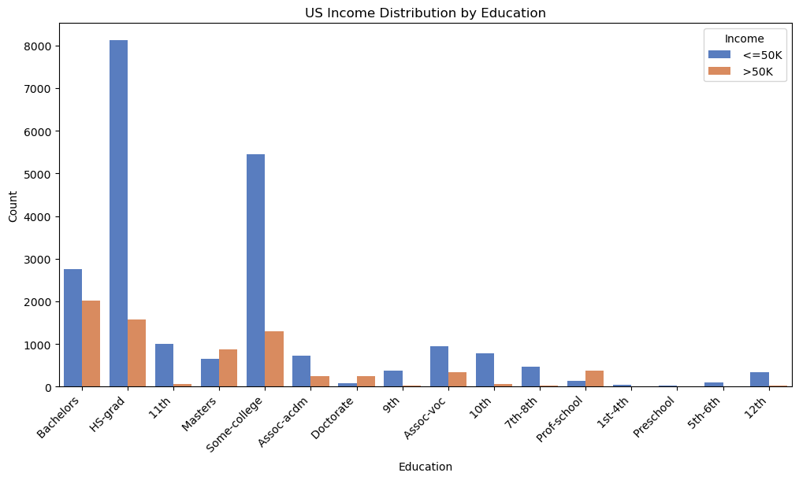

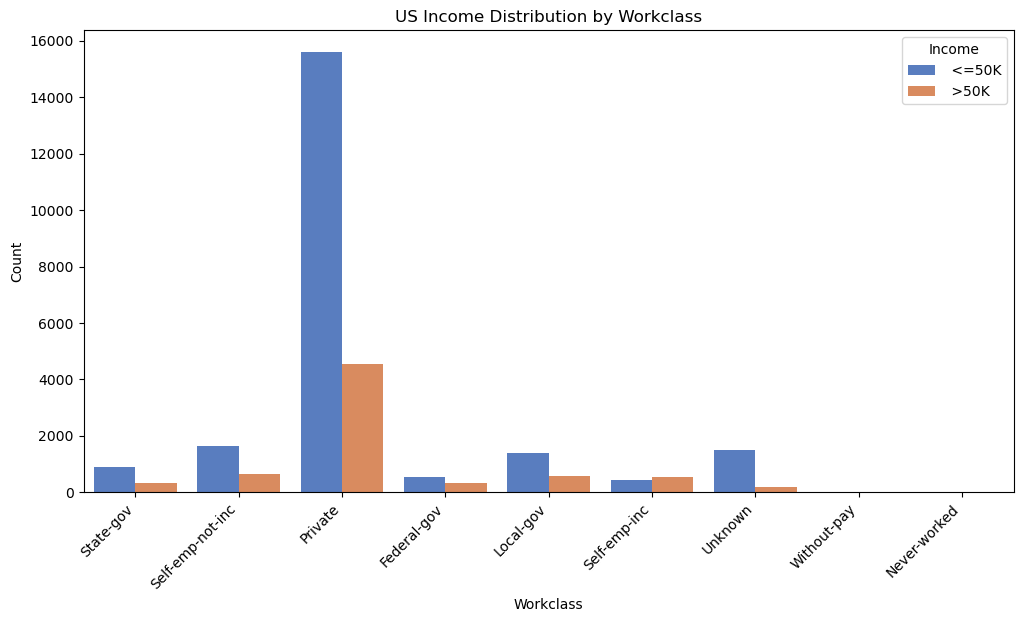

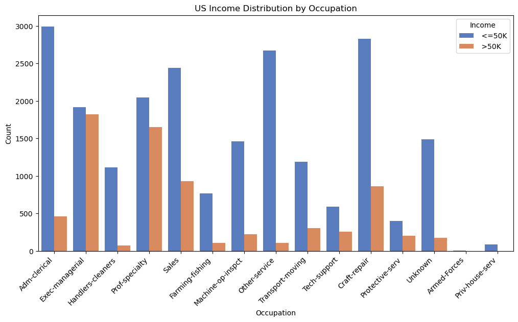

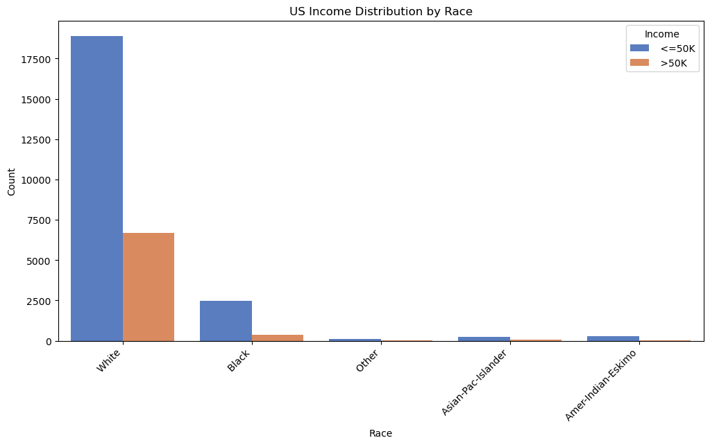

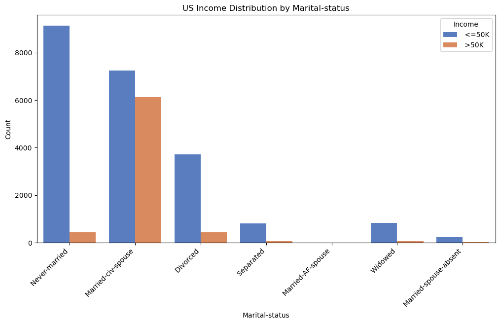

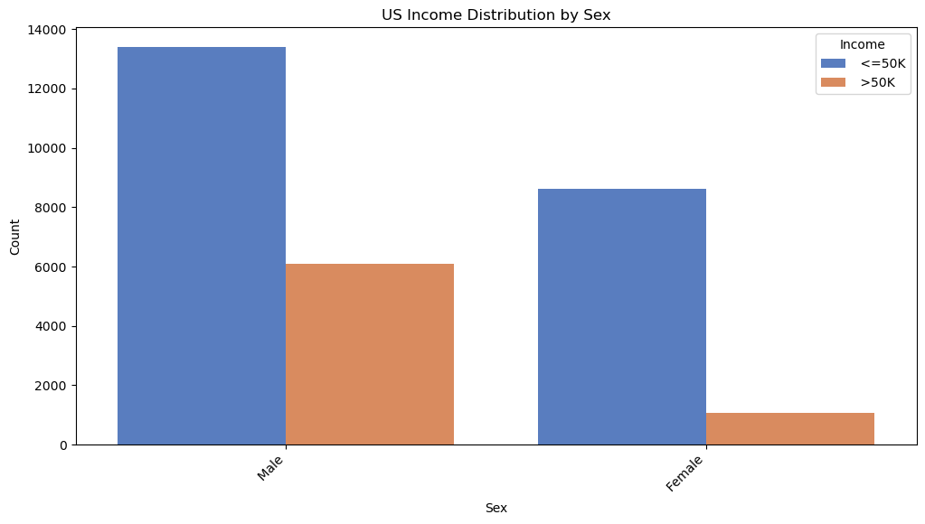

```python
# Analyze the impact of individual features on income using grouped bar plots in US population
features_of_interest = ['Education', 'Workclass', 'Occupation', 'Race', 'Marital-status', 'Sex']

for feature in features_of_interest:
    plt.figure(figsize=(12, 6))
    sns.countplot(x=feature, hue='Income', data=US_country_df, palette='muted')
    plt.title(f'US Income Distribution by {feature}')
    plt.xlabel(feature)
    plt.ylabel('Count')
    plt.xticks(rotation=45, ha='right')
    plt.show()
```